# `R` for DataFest @ OSU

David Dalpiaz

Thursday, March 21, 2019

[figure not shown]

[figure not shown]

# Tools

- [`R`!](https://www.r-project.org/)
- [RStudio](https://www.rstudio.com/)
- The [`tidyverse`](https://www.tidyverse.org/)
- [RMarkdown](https://rmarkdown.rstudio.com/)

# `R` and RStudio Versions

```r
version
```

```
##                _
## platform       x86_64-apple-darwin15.6.0
## arch           x86_64
## os             darwin15.6.0
## system         x86_64, darwin15.6.0
## status
## major          3
## minor          5.2
## year           2018
## month          12
## day            20
## svn rev        75870
## language       R
## version.string R version 3.5.2 (2018-12-20)
## nickname       Eggshell Igloo
```

# Packages

[figure not shown]

```r
library("tidyverse")
library("lubridate")
update.packages()
```

# Import Data as Tibbles (`tibble`) with `reader`

For this tutorial we will use data on the [OSU Men’s Basketball games from the 2018 - 2019 season](https://www.sports-reference.com/cbb/schools/ohio-state/2019-gamelogs.html), excluding any games in the ongoing [2019 NCAA Tournament](http://www.espn.com/mens-college-basketball/tournament/bracket/_/id/201922/2019-ncaa-tournament) where OSU is an 11 seed. While an 11 seed isn’t great, have a look at [this video](https://www.youtube.com/watch?v=4a1TUszkMfI) by Jon Bois which explains some of the weirdness around certain seeds in the tournament.

(This data was not used during the live tutorial, but is much easier to understand, and better for sharing publicly.)

```r
osu_bb = read_csv(file = "data/osu-bb-2019-games.csv")
```

```r
osu_bb = read_csv("data/osu-bb-2019-games.csv",
    col_types = cols(Date = col_date(format = "%m-%d-%y"),
                     # OPPPF = col_skip(),
                     # OPPTOV = col_skip(),
                     `3PPERC` = col_number(),
                     FGPERC = col_number(),
                     FTPERC = col_number(),
                     OPP3PPERC = col_number(),
                     OPPFGPERC = col_number(),
                     OPPFTPERC = col_number()))
```

```r
osu_bb
```

| Game | Date | Home | Opponent | Outcome | PTS | OPPPTS | FG | FGA | FGPERC | 3P | 3PA | 3PPERC | FT | FTA | FTPERC | ORB | TRB | AST | STL | BLK | TOV | PF | OPPFG | OPPFGA | OPPFGPERC | OPP3P | OPP3PA | OPP3PPERC | OPPFT | … |
| --- | --- | --- | --- | --- | --- | --- | --- | --- | --- | --- | --- | --- | --- | --- | --- | --- | --- | --- | --- | --- | --- | --- | --- | --- | --- | --- | --- | --- | --- | --- |
| 1 | 2018-11-07 | @ | Cincinnati | W | 64 | 56 | 20 | 47 | 42.6 | 8 | 20 | 40.0 | 16 | 22 | 72.7 | 6 | 27 | 7 | 2 | 5 | 13 | 22 | 17 | 62 | 27.4 | 6 | 26 | 23.1 | 16 | … |
| 2 | 2018-11-11 | NA | Purdue-Fort Wayne | W | 107 | 61 | 34 | 56 | 60.7 | 15 | 28 | 53.6 | 24 | 28 | 85.7 | 6 | 35 | 21 | 6 | 5 | 11 | 18 | 22 | 65 | 33.8 | 6 | 27 | 22.2 | 11 | … |
| 3 | 2018-11-15 | @ | Creighton | W | 69 | 60 | 26 | 55 | 47.3 | 10 | 21 | 47.6 | 7 | 12 | 58.3 | 11 | 31 | 15 | 4 | 2 | 13 | 18 | 23 | 52 | 44.2 | 9 | 25 | 36.0 | 5 | … |
| 4 | 2018-11-18 | NA | South Carolina State | W | 89 | 61 | 28 | 51 | 54.9 | 7 | 19 | 36.8 | 26 | 35 | 74.3 | 7 | 37 | 18 | 4 | 3 | 15 | 17 | 23 | 62 | 37.1 | 3 | 19 | 15.8 | 12 | … |
| 5 | 2018-11-20 | NA | Samford | W | 68 | 50 | 23 | 52 | 44.2 | 3 | 20 | 15.0 | 19 | 28 | 67.9 | 7 | 36 | 14 | 4 | 2 | 12 | 13 | 21 | 57 | 36.8 | 4 | 15 | 26.7 | 4 | … |
| 6 | 2018-11-23 | NA | Cleveland State | W | 89 | 62 | 34 | 64 | 53.1 | 7 | 19 | 36.8 | 14 | 19 | 73.7 | 7 | 34 | 17 | 11 | 3 | 12 | 21 | 21 | 60 | 35.0 | 6 | 21 | 28.6 | 14 | … |
| 7 | 2018-11-28 | NA | Syracuse | L | 62 | 72 | 15 | 46 | 32.6 | 6 | 22 | 27.3 | 26 | 35 | 74.3 | 8 | 28 | 12 | 5 | 1 | 10 | 17 | 22 | 45 | 48.9 | 11 | 24 | 45.8 | 17 | … |
| 8 | 2018-12-02 | NA | Minnesota | W | 79 | 59 | 28 | 60 | 46.7 | 7 | 17 | 41.2 | 16 | 20 | 80.0 | 11 | 39 | 16 | 5 | 1 | 10 | 26 | 20 | 51 | 39.2 | 0 | 13 | 0.0 | 19 | … |
| 9 | 2018-12-05 | N | Illinois | W | 77 | 67 | 24 | 51 | 47.1 | 6 | 17 | 35.3 | 23 | 32 | 71.9 | 9 | 36 | 14 | 8 | 4 | 19 | 22 | 19 | 58 | 32.8 | 6 | 19 | 31.6 | 23 | … |
| 10 | 2018-12-15 | NA | Bucknell | W | 73 | 71 | 27 | 56 | 48.2 | 6 | 15 | 40.0 | 13 | 18 | 72.2 | 9 | 39 | 15 | 2 | 3 | 13 | 14 | 23 | 55 | 41.8 | 12 | 30 | 40.0 | 13 | … |

[output cut: 23 more lines]

```r
View(osu_bb)
```

# Tidy Data


# Data Wrangling with `dplyr` and Friends

## Data Formatting

- “Import Dataset” Tool
- `lubridate`
- `stringr`
- `forcats`

```r
osu_bb$Date[1:5]
```

```
## [1] "2018-11-07" "2018-11-11" "2018-11-15" "2018-11-18" "2018-11-20"
```

```r
day(osu_bb$Date[1:5])
```

```
## [1]  7 11 15 18 20
```

```r
yday(osu_bb$Date[1:5])
```

```
## [1] 311 315 319 322 324
```

```r
week(osu_bb$Date[1:5])
```

```
## [1] 45 45 46 46 47
```

```r
year(osu_bb$Date[1:5])
```

```
## [1] 2018 2018 2018 2018 2018
```

```r
month(osu_bb$Date[1:5])
```

```
## [1] 11 11 11 11 11
```

```r
unique(osu_bb$Opponent)[1:20]
```

```
##  [1] "Cincinnati"           "Purdue-Fort Wayne"    "Creighton"
##  [4] "South Carolina State" "Samford"              "Cleveland State"
##  [7] "Syracuse"             "Minnesota"            "Illinois"
## [10] "Bucknell"             "Youngstown State"     "UCLA"
## [13] "High Point"           "Michigan State"       "Rutgers"
## [16] "Iowa"                 "Maryland"             "Purdue"
## [19] "Nebraska"             "Michigan"
```

```r
str_count(unique(osu_bb$Opponent)[1:20])
```

```
##  [1] 10 17  9 20  7 15  8  9  8  8 16  4 10 14  7  4  8  6  8  8
```

```r
str_subset(unique(osu_bb$Opponent)[1:20], "State")
```

```
## [1] "South Carolina State" "Cleveland State"      "Youngstown State"
## [4] "Michigan State"
```

```r
str_locate(unique(osu_bb$Opponent)[1:20], "State")
```

```
##       start end
##  [1,]    NA  NA
##  [2,]    NA  NA
##  [3,]    NA  NA
##  [4,]    16  20
##  [5,]    NA  NA
##  [6,]    11  15
##  [7,]    NA  NA
##  [8,]    NA  NA
##  [9,]    NA  NA
## [10,]    NA  NA
## [11,]    12  16
## [12,]    NA  NA
## [13,]    NA  NA
## [14,]    10  14
## [15,]    NA  NA
## [16,]    NA  NA
## [17,]    NA  NA
## [18,]    NA  NA
## [19,]    NA  NA
## [20,]    NA  NA
```

```r
head(osu_bb$Home)
```

```
## [1] "@" NA  "@" NA  NA  NA
```

```r
unique(osu_bb$Home)
```

```
## [1] "@" NA  "N"
```

```r
# change NAs to H for "home"
osu_bb$Home = fct_explicit_na(osu_bb$Home, "H")
```

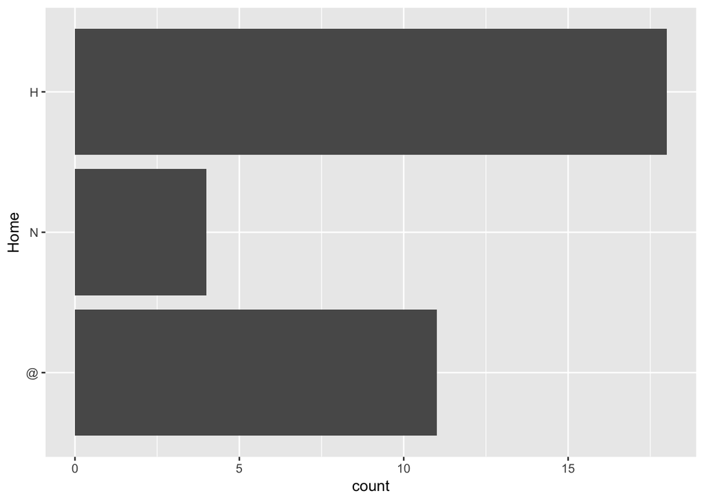

```r
ggplot(osu_bb, aes(x = Home)) +
  geom_bar() +
  coord_flip()
```

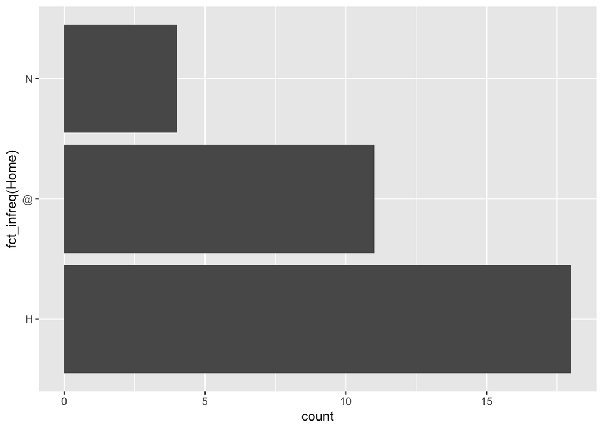

```r
ggplot(osu_bb, aes(x = fct_infreq(Home))) +
  geom_bar() +
  coord_flip()
```

```r
levels(as.factor(osu_bb$Home))
```

```
## [1] "@" "N" "H"
```

```r
levels(fct_infreq(osu_bb$Home))
```

```
## [1] "H" "@" "N"
```

## One-Table `dplyr` Verbs

- `mutate()` - Create new variables
- `select()` - Working with columns
- `filter()` - Working with rows
- `arrange()` - Reordering rows
- `summarise()` - Reduce data to summary statistics
- `group_by()` - Use above operations on “groups” in the data

```r
filter(osu_bb, Home == "@")
```

| Game | Date | Home | Opponent | Outcome | PTS | OPPPTS | FG | FGA | FGPERC | 3P | 3PA | 3PPERC | FT | FTA | FTPERC | ORB | TRB | AST | STL | BLK | TOV | PF | OPPFG | OPPFGA | OPPFGPERC | OPP3P | OPP3PA | OPP3PPERC | OPPFT | … |
| --- | --- | --- | --- | --- | --- | --- | --- | --- | --- | --- | --- | --- | --- | --- | --- | --- | --- | --- | --- | --- | --- | --- | --- | --- | --- | --- | --- | --- | --- | --- |
| 1 | 2018-11-07 | @ | Cincinnati | W | 64 | 56 | 20 | 47 | 42.6 | 8 | 20 | 40.0 | 16 | 22 | 72.7 | 6 | 27 | 7 | 2 | 5 | 13 | 22 | 17 | 62 | 27.4 | 6 | 26 | 23.1 | 16 | … |
| 3 | 2018-11-15 | @ | Creighton | W | 69 | 60 | 26 | 55 | 47.3 | 10 | 21 | 47.6 | 7 | 12 | 58.3 | 11 | 31 | 15 | 4 | 2 | 13 | 18 | 23 | 52 | 44.2 | 9 | 25 | 36.0 | 5 | … |
| 15 | 2019-01-09 | @ | Rutgers | L | 61 | 64 | 23 | 58 | 39.7 | 8 | 26 | 30.8 | 7 | 11 | 63.6 | 10 | 28 | 12 | 7 | 0 | 12 | 18 | 22 | 53 | 41.5 | 5 | 16 | 31.3 | 15 | … |
| 16 | 2019-01-12 | @ | Iowa | L | 62 | 72 | 22 | 59 | 37.3 | 10 | 25 | 40.0 | 8 | 11 | 72.7 | 11 | 36 | 14 | 9 | 1 | 20 | 23 | 25 | 55 | 45.5 | 4 | 16 | 25.0 | 18 | … |
| 19 | 2019-01-26 | @ | Nebraska | W | 70 | 60 | 24 | 58 | 41.4 | 9 | 27 | 33.3 | 13 | 18 | 72.2 | 12 | 42 | 8 | 8 | 1 | 12 | 14 | 21 | 58 | 36.2 | 8 | 22 | 36.4 | 10 | … |
| 20 | 2019-01-29 | @ | Michigan | L | 49 | 65 | 19 | 52 | 36.5 | 5 | 21 | 23.8 | 6 | 6 | 100.0 | 10 | 34 | 10 | 4 | 4 | 18 | 18 | 22 | 54 | 40.7 | 10 | 27 | 37.0 | 11 | … |
| 23 | 2019-02-10 | @ | Indiana | W | 55 | 52 | 23 | 52 | 44.2 | 7 | 16 | 43.8 | 2 | 6 | 33.3 | 7 | 29 | 13 | 5 | 4 | 15 | 15 | 21 | 53 | 39.6 | 6 | 20 | 30.0 | 4 | … |
| 25 | 2019-02-17 | @ | Michigan State | L | 44 | 62 | 18 | 56 | 32.1 | 4 | 15 | 26.7 | 4 | 9 | 44.4 | 7 | 34 | 9 | 7 | 2 | 15 | 18 | 21 | 55 | 38.2 | 10 | 26 | 38.5 | 10 | … |
| 27 | 2019-02-23 | @ | Maryland | L | 62 | 72 | 23 | 63 | 36.5 | 11 | 33 | 33.3 | 5 | 7 | 71.4 | 9 | 27 | 14 | 9 | 3 | 7 | 18 | 23 | 47 | 48.9 | 6 | 17 | 35.3 | 20 | … |
| 29 | 2019-03-02 | @ | Purdue | L | 51 | 86 | 16 | 48 | 33.3 | 2 | 19 | 10.5 | 17 | 25 | 68.0 | 7 | 23 | 9 | 5 | 1 | 9 | 18 | 33 | 59 | 55.9 | 11 | 21 | 52.4 | 9 | … |

[output cut: 1 more lines]

```r
osu_bb %>% filter(Home == "@")
```

| Game | Date | Home | Opponent | Outcome | PTS | OPPPTS | FG | FGA | FGPERC | 3P | 3PA | 3PPERC | FT | FTA | FTPERC | ORB | TRB | AST | STL | BLK | TOV | PF | OPPFG | OPPFGA | OPPFGPERC | OPP3P | OPP3PA | OPP3PPERC | OPPFT | … |
| --- | --- | --- | --- | --- | --- | --- | --- | --- | --- | --- | --- | --- | --- | --- | --- | --- | --- | --- | --- | --- | --- | --- | --- | --- | --- | --- | --- | --- | --- | --- |
| 1 | 2018-11-07 | @ | Cincinnati | W | 64 | 56 | 20 | 47 | 42.6 | 8 | 20 | 40.0 | 16 | 22 | 72.7 | 6 | 27 | 7 | 2 | 5 | 13 | 22 | 17 | 62 | 27.4 | 6 | 26 | 23.1 | 16 | … |
| 3 | 2018-11-15 | @ | Creighton | W | 69 | 60 | 26 | 55 | 47.3 | 10 | 21 | 47.6 | 7 | 12 | 58.3 | 11 | 31 | 15 | 4 | 2 | 13 | 18 | 23 | 52 | 44.2 | 9 | 25 | 36.0 | 5 | … |
| 15 | 2019-01-09 | @ | Rutgers | L | 61 | 64 | 23 | 58 | 39.7 | 8 | 26 | 30.8 | 7 | 11 | 63.6 | 10 | 28 | 12 | 7 | 0 | 12 | 18 | 22 | 53 | 41.5 | 5 | 16 | 31.3 | 15 | … |
| 16 | 2019-01-12 | @ | Iowa | L | 62 | 72 | 22 | 59 | 37.3 | 10 | 25 | 40.0 | 8 | 11 | 72.7 | 11 | 36 | 14 | 9 | 1 | 20 | 23 | 25 | 55 | 45.5 | 4 | 16 | 25.0 | 18 | … |
| 19 | 2019-01-26 | @ | Nebraska | W | 70 | 60 | 24 | 58 | 41.4 | 9 | 27 | 33.3 | 13 | 18 | 72.2 | 12 | 42 | 8 | 8 | 1 | 12 | 14 | 21 | 58 | 36.2 | 8 | 22 | 36.4 | 10 | … |
| 20 | 2019-01-29 | @ | Michigan | L | 49 | 65 | 19 | 52 | 36.5 | 5 | 21 | 23.8 | 6 | 6 | 100.0 | 10 | 34 | 10 | 4 | 4 | 18 | 18 | 22 | 54 | 40.7 | 10 | 27 | 37.0 | 11 | … |
| 23 | 2019-02-10 | @ | Indiana | W | 55 | 52 | 23 | 52 | 44.2 | 7 | 16 | 43.8 | 2 | 6 | 33.3 | 7 | 29 | 13 | 5 | 4 | 15 | 15 | 21 | 53 | 39.6 | 6 | 20 | 30.0 | 4 | … |
| 25 | 2019-02-17 | @ | Michigan State | L | 44 | 62 | 18 | 56 | 32.1 | 4 | 15 | 26.7 | 4 | 9 | 44.4 | 7 | 34 | 9 | 7 | 2 | 15 | 18 | 21 | 55 | 38.2 | 10 | 26 | 38.5 | 10 | … |
| 27 | 2019-02-23 | @ | Maryland | L | 62 | 72 | 23 | 63 | 36.5 | 11 | 33 | 33.3 | 5 | 7 | 71.4 | 9 | 27 | 14 | 9 | 3 | 7 | 18 | 23 | 47 | 48.9 | 6 | 17 | 35.3 | 20 | … |
| 29 | 2019-03-02 | @ | Purdue | L | 51 | 86 | 16 | 48 | 33.3 | 2 | 19 | 10.5 | 17 | 25 | 68.0 | 7 | 23 | 9 | 5 | 1 | 9 | 18 | 33 | 59 | 55.9 | 11 | 21 | 52.4 | 9 | … |

[output cut: 1 more lines]

```r
osu_bb %>% filter(Home == "@") %>% View()
```

```r
osu_bb %>% filter(Home == "@", OPPPTS < 60)
```

| Game | Date | Home | Opponent | Outcome | PTS | OPPPTS | FG | FGA | FGPERC | 3P | 3PA | 3PPERC | FT | FTA | FTPERC | ORB | TRB | AST | STL | BLK | TOV | PF | OPPFG | OPPFGA | OPPFGPERC | OPP3P | OPP3PA | OPP3PPERC | OPPFT | … |
| --- | --- | --- | --- | --- | --- | --- | --- | --- | --- | --- | --- | --- | --- | --- | --- | --- | --- | --- | --- | --- | --- | --- | --- | --- | --- | --- | --- | --- | --- | --- |
| 1 | 2018-11-07 | @ | Cincinnati | W | 64 | 56 | 20 | 47 | 42.6 | 8 | 20 | 40.0 | 16 | 22 | 72.7 | 6 | 27 | 7 | 2 | 5 | 13 | 22 | 17 | 62 | 27.4 | 6 | 26 | 23.1 | 16 | … |
| 23 | 2019-02-10 | @ | Indiana | W | 55 | 52 | 23 | 52 | 44.2 | 7 | 16 | 43.8 | 2 | 6 | 33.3 | 7 | 29 | 13 | 5 | 4 | 15 | 15 | 21 | 53 | 39.6 | 6 | 20 | 30.0 | 4 | … |

```r
osu_bb %>% filter(Home == "@") %>%
  summarize(avg_fg = mean(FG))
```

| avg_fg |
| --- |
| 21 |

```r
osu_bb %>% filter(Home == "@") %>%
  summarize(avg_fg = mean(FG)) %>% unlist()
```

```
## avg_fg
##     21
```

```r
osu_bb %>% filter(Home == "@") %>%
  summarize(avg_fg = mean(FG), sd_fg = sd(FG))
```

| avg_fg | sd_fg |
| --- | --- |
| 21 | 3.193744 |

```r
osu_bb %>% filter(Home == "@") %>%
  count(Outcome)
```

| Outcome | n |
| --- | --- |
| L | 7 |
| W | 4 |

```r
osu_bb %>% filter(Outcome == "W") %>%
  count(Home) %>% arrange(-n)
```

| Home | n |
| --- | --- |
| H | 12 |
| @ | 4 |
| N | 3 |

```r
osu_bb %>% filter(Home == "@") %>%
  arrange(`3P`, desc(`3PPERC`)) %>% select(Date, Home, Opponent, Outcome, `3P`, `3PPERC`)
```

| Date | Home | Opponent | Outcome | 3P | 3PPERC |
| --- | --- | --- | --- | --- | --- |
| 2019-03-02 | @ | Purdue | L | 2 | 10.5 |
| 2019-02-17 | @ | Michigan State | L | 4 | 26.7 |
| 2019-03-06 | @ | Northwestern | L | 4 | 15.4 |
| 2019-01-29 | @ | Michigan | L | 5 | 23.8 |
| 2019-02-10 | @ | Indiana | W | 7 | 43.8 |
| 2018-11-07 | @ | Cincinnati | W | 8 | 40.0 |
| 2019-01-09 | @ | Rutgers | L | 8 | 30.8 |
| 2019-01-26 | @ | Nebraska | W | 9 | 33.3 |
| 2018-11-15 | @ | Creighton | W | 10 | 47.6 |
| 2019-01-12 | @ | Iowa | L | 10 | 40.0 |

[output cut: 1 more lines]

```r
osu_bb %>% summarize(avg_ft = mean(FT))
```

| avg_ft |
| --- |
| 13.78788 |

```r
osu_bb %>% group_by(Home) %>% summarize(avg_ft = mean(FT))
```

| Home | avg_ft |
| --- | --- |
| @ | 8.818182 |
| N | 16.000000 |
| H | 16.333333 |

```r
osu_bb %>% group_by(Home) %>%
  summarize(n_ft = sum(FT),
            avg_ft = mean(FT),
            sd_ft = sd(FT),
            max_ft = max(FT)) %>%
  arrange(-n_ft)
```

| Home | n_ft | avg_ft | sd_ft | max_ft |
| --- | --- | --- | --- | --- |
| H | 294 | 16.333333 | 6.183469 | 26 |
| @ | 97 | 8.818182 | 4.956172 | 17 |
| N | 64 | 16.000000 | 5.354126 | 23 |

```r
osu_bb %>% mutate(shots = FG + FT, shots_2_idk = 2 * shots) %>%
  select(-OPPFG:-OPPPF)
```

| Game | Date | Home | Opponent | Outcome | PTS | OPPPTS | FG | FGA | FGPERC | 3P | 3PA | 3PPERC | FT | FTA | FTPERC | ORB | TRB | AST | STL | BLK | TOV | PF | shots | shots_2_idk |
| --- | --- | --- | --- | --- | --- | --- | --- | --- | --- | --- | --- | --- | --- | --- | --- | --- | --- | --- | --- | --- | --- | --- | --- | --- |
| 1 | 2018-11-07 | @ | Cincinnati | W | 64 | 56 | 20 | 47 | 42.6 | 8 | 20 | 40.0 | 16 | 22 | 72.7 | 6 | 27 | 7 | 2 | 5 | 13 | 22 | 36 | 72 |
| 2 | 2018-11-11 | H | Purdue-Fort Wayne | W | 107 | 61 | 34 | 56 | 60.7 | 15 | 28 | 53.6 | 24 | 28 | 85.7 | 6 | 35 | 21 | 6 | 5 | 11 | 18 | 58 | 116 |
| 3 | 2018-11-15 | @ | Creighton | W | 69 | 60 | 26 | 55 | 47.3 | 10 | 21 | 47.6 | 7 | 12 | 58.3 | 11 | 31 | 15 | 4 | 2 | 13 | 18 | 33 | 66 |
| 4 | 2018-11-18 | H | South Carolina State | W | 89 | 61 | 28 | 51 | 54.9 | 7 | 19 | 36.8 | 26 | 35 | 74.3 | 7 | 37 | 18 | 4 | 3 | 15 | 17 | 54 | 108 |
| 5 | 2018-11-20 | H | Samford | W | 68 | 50 | 23 | 52 | 44.2 | 3 | 20 | 15.0 | 19 | 28 | 67.9 | 7 | 36 | 14 | 4 | 2 | 12 | 13 | 42 | 84 |
| 6 | 2018-11-23 | H | Cleveland State | W | 89 | 62 | 34 | 64 | 53.1 | 7 | 19 | 36.8 | 14 | 19 | 73.7 | 7 | 34 | 17 | 11 | 3 | 12 | 21 | 48 | 96 |
| 7 | 2018-11-28 | H | Syracuse | L | 62 | 72 | 15 | 46 | 32.6 | 6 | 22 | 27.3 | 26 | 35 | 74.3 | 8 | 28 | 12 | 5 | 1 | 10 | 17 | 41 | 82 |
| 8 | 2018-12-02 | H | Minnesota | W | 79 | 59 | 28 | 60 | 46.7 | 7 | 17 | 41.2 | 16 | 20 | 80.0 | 11 | 39 | 16 | 5 | 1 | 10 | 26 | 44 | 88 |
| 9 | 2018-12-05 | N | Illinois | W | 77 | 67 | 24 | 51 | 47.1 | 6 | 17 | 35.3 | 23 | 32 | 71.9 | 9 | 36 | 14 | 8 | 4 | 19 | 22 | 47 | 94 |
| 10 | 2018-12-15 | H | Bucknell | W | 73 | 71 | 27 | 56 | 48.2 | 6 | 15 | 40.0 | 13 | 18 | 72.2 | 9 | 39 | 15 | 2 | 3 | 13 | 14 | 40 | 80 |

[output cut: 23 more lines]

## Two-Table `dplyr` Verbs

### Mutating Joins

- `inner_join(x, y)` only includes observations that match in both `x` and `y`
- `left_join(x, y)` includes all observations in `x`, regardless of whether they match or not
- `right_join(x, y)` includes all observations in `y`. It’s equivalent to `left_join(y, x)`, but the columns will be ordered differently
- `full_join()` includes all observations from `x` and `y`

```r
superheroes
```

| name | alignment | gender | publisher |
| --- | --- | --- | --- |
| Magneto | bad | male | Marvel |
| Storm | good | female | Marvel |
| Mystique | bad | female | Marvel |
| Batman | good | male | DC |
| Joker | bad | male | DC |
| Catwoman | bad | female | DC |
| Hellboy | good | male | Dark Horse Comics |

```r
publishers
```

| publisher | yr_founded |
| --- | --- |
| DC | 1934 |
| Marvel | 1939 |
| Image | 1992 |

```r
inner_join(superheroes, publishers)
```

| name | alignment | gender | publisher | yr_founded |
| --- | --- | --- | --- | --- |
| Magneto | bad | male | Marvel | 1939 |
| Storm | good | female | Marvel | 1939 |
| Mystique | bad | female | Marvel | 1939 |
| Batman | good | male | DC | 1934 |
| Joker | bad | male | DC | 1934 |
| Catwoman | bad | female | DC | 1934 |

```r
left_join(superheroes, publishers)
```

| name | alignment | gender | publisher | yr_founded |
| --- | --- | --- | --- | --- |
| Magneto | bad | male | Marvel | 1939 |
| Storm | good | female | Marvel | 1939 |
| Mystique | bad | female | Marvel | 1939 |
| Batman | good | male | DC | 1934 |
| Joker | bad | male | DC | 1934 |
| Catwoman | bad | female | DC | 1934 |
| Hellboy | good | male | Dark Horse Comics | NA |

### Filtering Joins

- `semi_join(x, y)` keeps all observations in `x` that have a match in `y`
- `anti_join(x, y)` drops all observations in `x` that have a match in `y`

# Visualisation with `ggplot2`

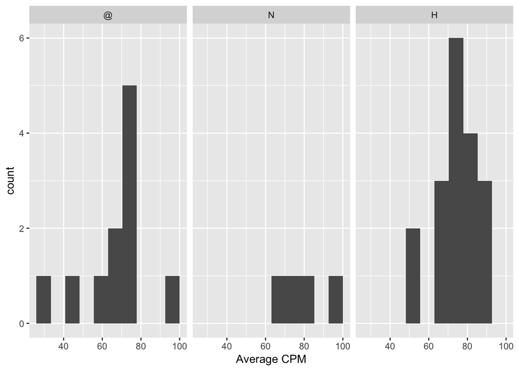

```r
osu_bb %>% ggplot(aes(x = FTPERC)) +
  geom_histogram(bins = 10) +
  facet_wrap(~Home) +
  labs(x = "Average CPM")
```

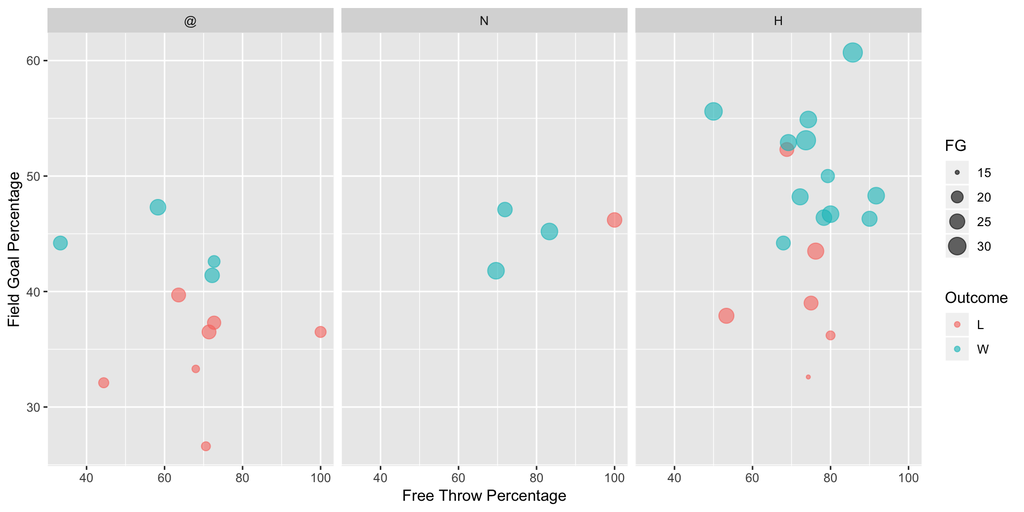

```r
osu_bb %>%
  ggplot(aes(x = FTPERC, y = FGPERC, color = Outcome, size = FG)) +
  geom_point(alpha = 0.6) +
  facet_wrap(~Home) +
  labs(x = "Free Throw Percentage", y = "Field Goal Percentage")
```

```r
osu_bb %>% filter(FGPERC < 30)
```

| Game | Date | Home | Opponent | Outcome | PTS | OPPPTS | FG | FGA | FGPERC | 3P | 3PA | 3PPERC | FT | FTA | FTPERC | ORB | TRB | AST | STL | BLK | TOV | PF | OPPFG | OPPFGA | OPPFGPERC | OPP3P | OPP3PA | OPP3PPERC | OPPFT | … |
| --- | --- | --- | --- | --- | --- | --- | --- | --- | --- | --- | --- | --- | --- | --- | --- | --- | --- | --- | --- | --- | --- | --- | --- | --- | --- | --- | --- | --- | --- | --- |
| 30 | 2019-03-06 | @ | Northwestern | L | 50 | 68 | 17 | 64 | 26.6 | 4 | 26 | 15.4 | 12 | 17 | 70.6 | 9 | 33 | 8 | 2 | 2 | 9 | 15 | 26 | 58 | 44.8 | 5 | 20 | 25 | 11 | … |

# Presentation with `rmarkdown`

[figure not shown]

# Resources

- [`R` for DataFest @ OSU](http://go.osu.edu/r4df)
- [`R` for Data Science](https://r4ds.had.co.nz/)
- [Advanced `R`](http://adv-r.had.co.nz/)
- [DataCamp](https://www.datacamp.com/)
- [RStudio Cheat Sheets](https://www.rstudio.com/resources/cheatsheets/)
- [`dplyr` Documentation](https://dplyr.tidyverse.org/)
- [Jenny Bryan’s `dply` `join()` Cheat Sheet](https://stat545.com/bit001_dplyr-cheatsheet.html)
- [RStudio Keyboard Shortcuts](https://support.rstudio.com/hc/en-us/articles/200711853-Keyboard-Shortcuts)